# Lab 6: Inference for Categorical Data

In August of 2012, news outlets ranging from the Washington Post to the Huffington Post ran a story about the rise of atheism in America. The source for the story was a poll that asked people, “Irrespective of whether you attend a place of worship or not, would you say you are a religious person, not a religious person or a convinced atheist?” This type of question, which asks people to classify themselves in one way or another, is common in polling and generates categorical data. In this lab we take a look at the atheism survey and explore what’s at play when making inference about population proportions using categorical data.

### The survey

To access the press release for the poll, conducted by WIN-Gallup International, click on the following link: http://www.wingia.com/web/files/richeditor/filemanager/Global_INDEX_of_Religiosity_and_Atheism_PR__6.pdf

Take a moment to review the report then address the following questions.

**Exercise 1** In the first paragraph, several key findings are reported. Do these percentages appear to be sample statistics (derived from the data sample) or population parameters?

The authors use language as if they are describing the population derived from a recent poll.

**Exercise 2** The title of the report is “Global Index of Religiosity and Atheism”. To generalize the report’s findings to the global human population, what must we assume about the sampling method? Does that seem like a reasonable assumption?

To make claims about the global population, then a random sample from all people globally must have been done. That is, all people should have been equally likely to have been polled.

### The data

Turn your attention to Table 6 (pages 15 and 16), which reports the sample size and response percentages for all 57 countries. While this is a useful format to summarize the data, we will base our analysis on the original data set of individual responses to the survey. Load this data set into R with the following command.

```r
if(!file.exists('atheism.RData')) {
    download.file('http://www.openintro.org/stat/data/atheism.RData', destfile = 'atheism.RData')
}
load("atheism.RData")
set.seed(2112) # This will ensure that the sample will return the same result each time.
```

**Exercise 3** What does each row of Table 6 correspond to? What does each row of atheism correspond to?

Each row in Table 6 corresponds to each countries results. Each row in `atheism` corresponds to an indivudal respondent.

To investigate the link between these two ways of organizing this data, take a look at the estimated proportion of atheists in the United States. Towards the bottom of Table 6, we see that this is 5%. We should be able to come to the same number using the atheism data.

**Exercise 4** Using the command below, create a new dataframe called us12 that contains only the rows in atheism associated with respondents to the 2012 survey from the United States. Next, calculate the proportion of atheist responses. Does it agree with the percentage in Table 6? If not, why?

```r
us12 <- subset(atheism, atheism$nationality == 'United States' & atheism$year == '2012')
tab <- table(us12$response)
prop.table(tab) * 100
```

```
##
##     atheist non-atheist
##        4.99       95.01
```

The percent of atheists agrees, however the `atheist` data frame only has a dichotomized variable for atheisism.

### Inference on proportions

As was hinted at in Exercise 1, Table 6 provides statistics, that is, calculations made from the sample of 51,927 people. What we’d like, though, is insight into the population parameters. You answer the question, “What proportion of people in your sample reported being atheists?” with a statistic; while the question “What proportion of people on earth would report being atheists” is answered with an estimate of the parameter.

The inferential tools for estimating population proportion are analogous to those used for means in the last chapter: the confidence interval and the hypothesis test.

**Exercise 5** Write out the conditions for inference to construct a 95% confidence interval for the proportion of atheists in the United States in 2012. Are you confident all conditions are met?

```r
table(us12$response)
```

```
##
##     atheist non-atheist
##          50         952
```

1. Independence. Assuming a random sample was used, this is assumption is met.  
2. Success-Failure. There were at least 10 responses for atheist and non-atheist.

If the conditions for inference are reasonable, we can either calculate the standard error and construct the interval by hand, or allow the inference function to do it for us.

```r
inference(y = us12$response, est = 'proportion', type = 'ci', method = 'theoretical', success = 'atheist')
```

```
## Single proportion -- success: atheist
## Summary statistics:
```

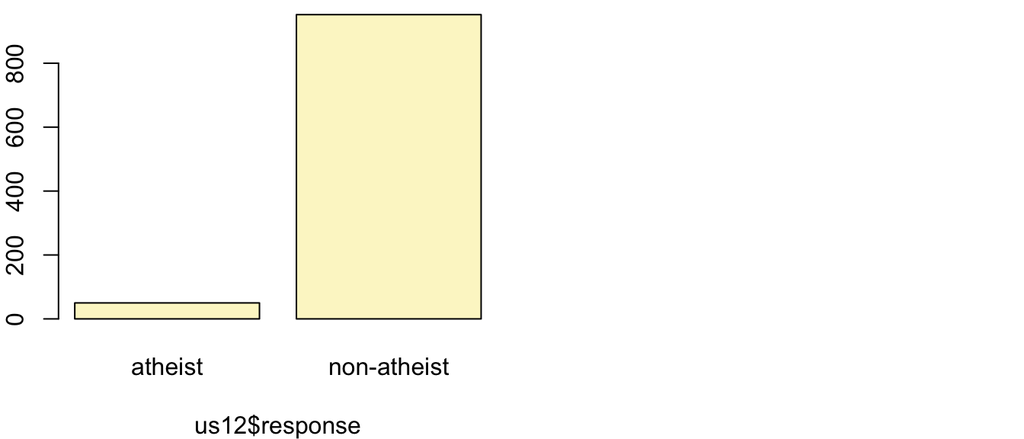

```
## p_hat = 0.0499 ;  n = 1002
## Check conditions: number of successes = 50 ; number of failures = 952
## Standard error = 0.0069
## 95 % Confidence interval = ( 0.0364 , 0.0634 )
```

Note that since the goal is to construct an interval estimate for a proportion, it’s necessary to specify what constitutes a “success”, which here is a response of atheist. Although formal confidence intervals and hypothesis tests don’t show up in the report, suggestions of inference appear at the bottom of page 7: “In general, the error margin for surveys of this kind is ±3 − 5% at 95% confidence.”

**Exercise 6** Based on the R output, what is the margin of error for the estimate of the proportion of the proportion of atheists in US in 2012?

The margin of error for the estimate of the proportion is 1.35% ($\frac{(0.0634 - 0.0364)}{2}$).

**Exercise 7** Using the inference function, calculate confidence intervals for the proportion of atheists in 2012 in two other countries of your choice, and report the associated margins of error. Be sure to note whether the conditions for inference are met. It may be helpful to create new data sets for each of the two countries first, and then use these data sets in the inference function to construct the confidence intervals.

```r
spain <- subset(atheism, nationality=='Spain' & year == 2012)
inference(y = spain$response, est = 'proportion', type = 'ci', method = 'theoretical', success = 'atheist')
```

```
## Single proportion -- success: atheist
## Summary statistics:
```

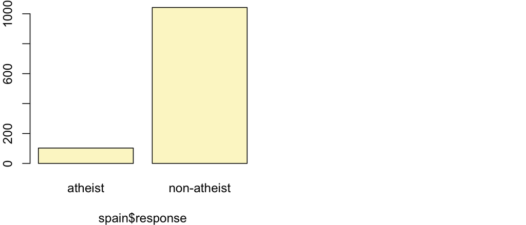

```
## p_hat = 0.09 ;  n = 1145
## Check conditions: number of successes = 103 ; number of failures = 1042
## Standard error = 0.0085
## 95 % Confidence interval = ( 0.0734 , 0.1065 )
```

```r
china <- subset(atheism, nationality=='China' & year == 2012)
inference(y = china$response, est = 'proportion', type = 'ci', method = 'theoretical', success = 'atheist')
```

```
## Single proportion -- success: atheist
## Summary statistics:
```

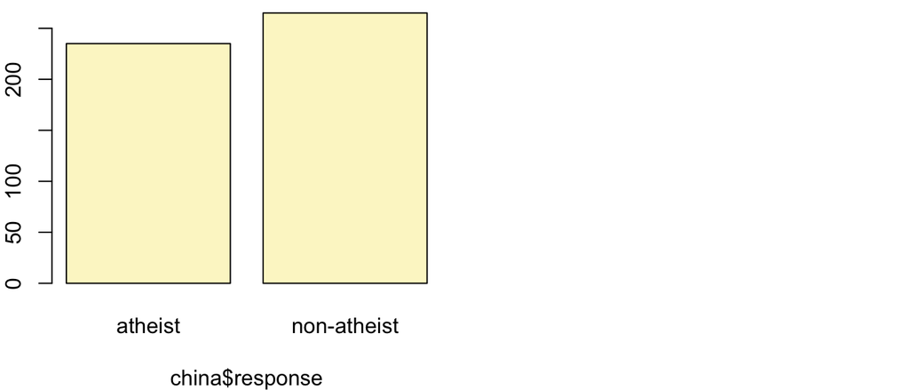

```
## p_hat = 0.47 ;  n = 500
## Check conditions: number of successes = 235 ; number of failures = 265
## Standard error = 0.0223
## 95 % Confidence interval = ( 0.4263 , 0.5137 )
```

```r
atheism2012 <- subset(atheism, year == 2012)
tab <- table(atheism2012$nationality, atheism2012$response)
# These are the countries that do not meet the success-failure condition.
tab[tab[,1] < 10 | tab[,2] < 10,]
```

```
##
##                atheist non-atheist
##   Afghanistan        0        1031
##   Azerbaijan         0         509
##   Ecuador            8         396
##   Ghana              0        1490
##   Iraq               0        1000
##   Malaysia           0         520
##   South Africa       8         194
##   Tunisia            0         498
##   Vietnam            0         500
```

[output not shown]

### How does the proportion affect the margin of error?

Imagine you’ve set out to survey 1000 people on two questions: are you female? and are you left-handed? Since both of these sample proportions were calculated from the same sample size, they should have the same margin of error, right? Wrong! While the margin of error does change with sample size, it is also affected by the proportion.

Think back to the formula for the standard error: $SE = \sqrt{\frac{p(1-p)}{n}}$. This is then used in the formula for the margin of error for a 95% confidence interval: $ME 1.96 x SE = 1.96 x \sqrt{\frac{p(1-p)}{n}}$. Since the population proportion p is in this ME formula, it should make sense that the margin of error is in some way dependent on the population proportion. We can visualize this relationship by creating a plot of ME vs. p.

The first step is to make a vector p that is a sequence from 0 to 1 with each number separated by 0.01. We can then create a vector of the margin of error (me) associated with each of these values of p using the familiar approximate formula (ME = 2 × SE). Lastly, we plot the two vectors against each other to reveal their relationship.

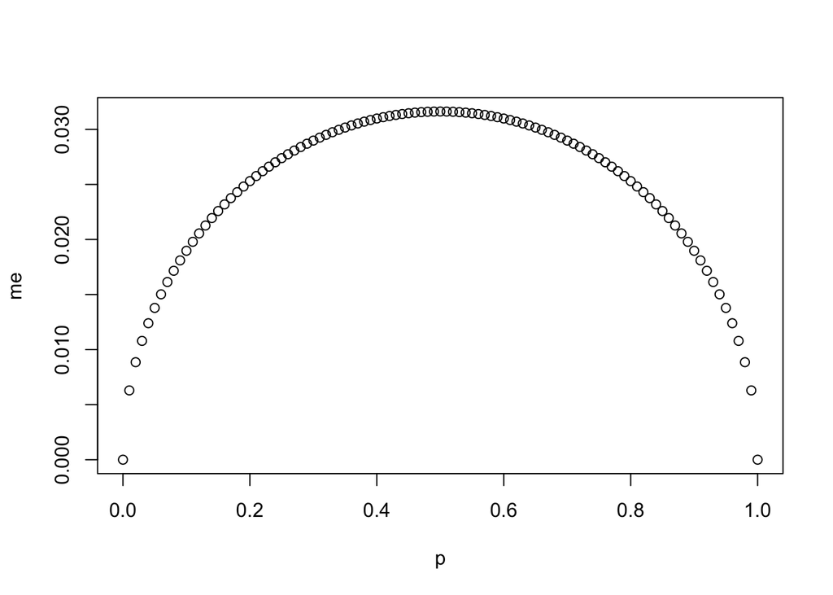

```r
n <- 1000
p <- seq(0, 1, 0.01)
me <- 2 * sqrt(p * (1 - p)/n)
plot(me ~ p)
```

**Exercise 8** Describe the relationship between p and me.

The margin of error will be largest when the proportions are 50%.

### Success-failure condition

The textbook emphasizes that you must always check conditions before making inference. For inference on proportions, the sample proportion can be assumed to be nearly normal if it is based upon a random sample of independent observations and if both np ≥ 10 and n(1 − p) ≥ 10. This rule of thumb is easy enough to follow, but it makes one wonder: what’s so special about the number 10? The short answer is: nothing. You could argue that we would be fine with 9 or that we really should be using 11. What is the “best” value for such a rule of thumb is, at least to some degree, arbitrary.

We can investigate the interplay between n and p and the shape of the sampling distribution by using simulations. To start off, we simulate the process of drawing 5000 samples of size 1040 from a population with a true atheist proportion of 0.1. For each of the 5000 samples we compute $\hat{p}$ and then plot a histogram to visualize their distribution.

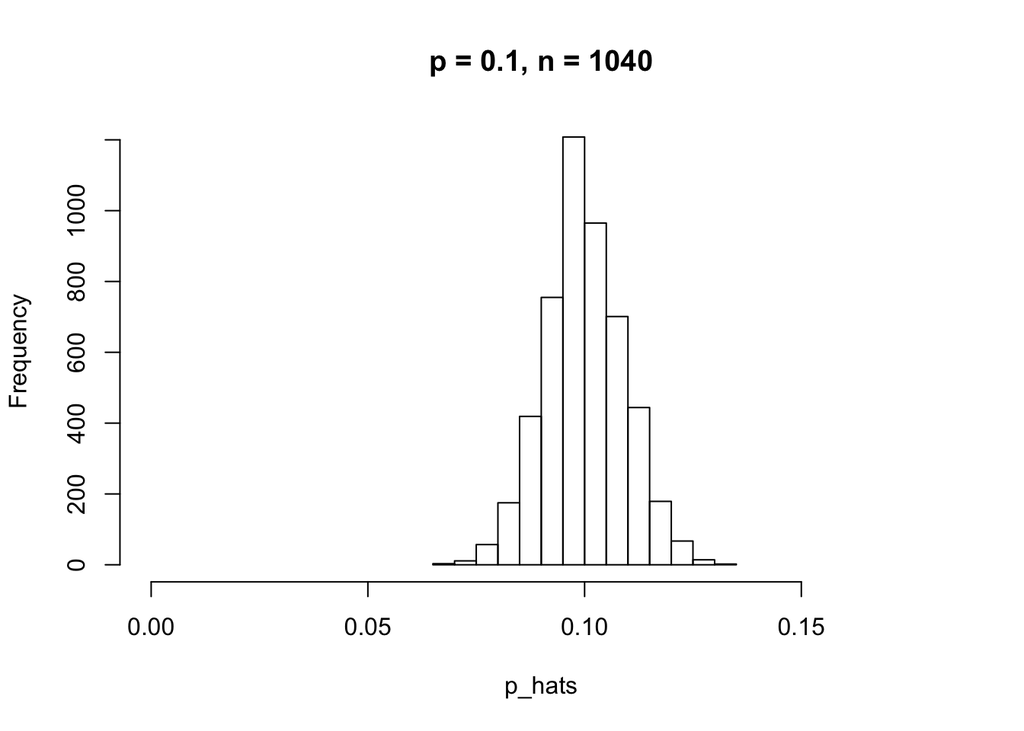

```r
p <- 0.1
n <- 1040
p_hats <- rep(0, 5000)
for (i in 1:5000) {
samp <- sample(c("atheist", "non_atheist"), n, replace = TRUE, prob = c(p,
        1 - p))
    p_hats[i] <- sum(samp == "atheist")/n
}
hist(p_hats, main = "p = 0.1, n = 1040", xlim = c(0, 0.18))
```

These commands build up the sampling distribution of p hats using the familiar for loop. You can read the sampling procedure for the first line of code inside the for loop as, “take a sample of size n with replacement from the choices of atheist and non-atheist with probabilities p and 1 − p, respectively.” The second line in the loop says, “calculate the proportion of atheists in this sample and record this value.” The loop allows us to repeat this process 5,000 times to build a good representation of the sampling distribution.

**Exercise 9** Describe the sampling distribution of sample proportions at n = 1040 and p = 0.1. Be sure to note the center, spread, and shape.  
Hint: Remember that R has functions such as mean to calculate summary statistics.

```r
summary(p_hats)
```

```
##    Min. 1st Qu.  Median    Mean 3rd Qu.    Max.
##  0.0663  0.0940  0.1000  0.1000  0.1070  0.1340
```

The distribution is normal, centered around 0.1001.

**Exercise 10** Replicate the above simulation three more times but with modified sample sizes andproportions: for `n=400` and `p=0.1`, `n=1040` and `p=0.02`, and `n=400` and `p= 0.02`. Plot all four histograms together by running the `par(mfrow = c(2,2))` command before creating the histograms. You may need to expand the plot window to accommodate the larger two-by-two plot. Describe the three new sampling distributions. Based on these limited plots, how does n appear to affect the distribution of pˆ? How does p affect the sampling distribution?

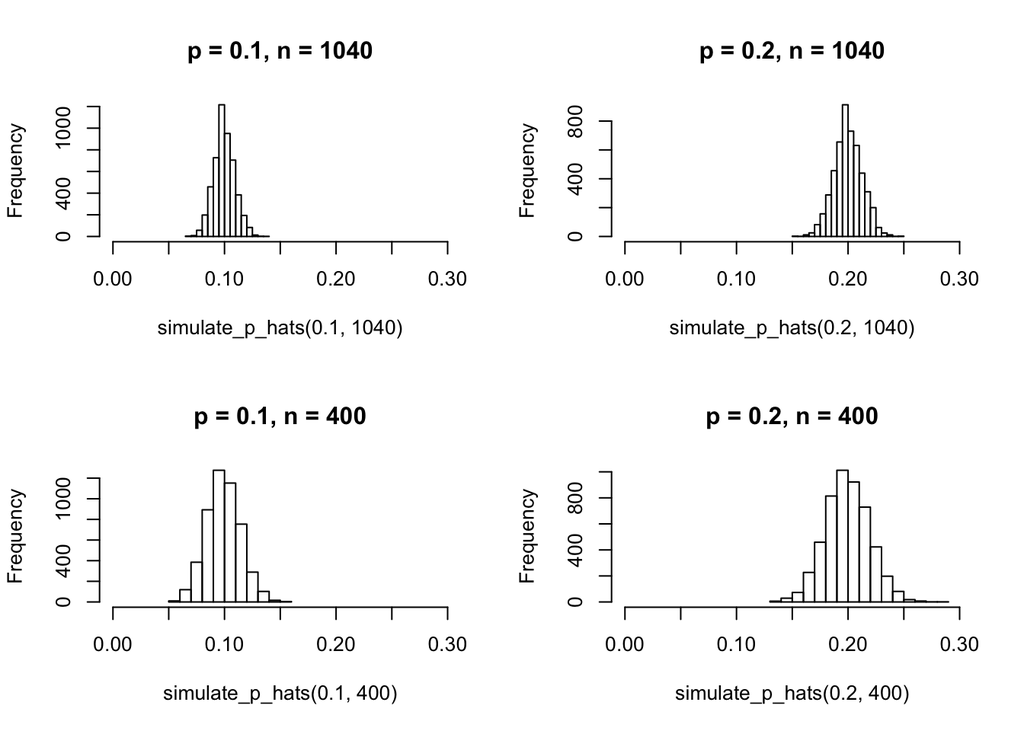

```r
simulate_p_hats <- function(p, n, size=5000) {
    p_hats <- rep(0, size)
    for (i in 1:size) {
        samp <- sample(c("atheist", "non_atheist"), n, replace = TRUE, prob = c(p, 1 - p))
        p_hats[i] <- sum(samp == "atheist")/n
    }
    return(p_hats)
}

par(mfrow = c(2,2))
hist(simulate_p_hats(.1, 1040), main = "p = 0.1, n = 1040", xlim = c(0, 0.3))
hist(simulate_p_hats(.2, 1040), main = "p = 0.2, n = 1040", xlim = c(0, 0.3))
hist(simulate_p_hats(.1, 400), main = "p = 0.1, n = 400", xlim = c(0, 0.3))
hist(simulate_p_hats(.2, 400), main = "p = 0.2, n = 400", xlim = c(0, 0.3))
```

```r
par(mfrow = c(1,1))
```

Once you’re done, you can reset the layout of the plotting window by using the command `par(mfrow = c(1,1))` or clicking on “Clear All” above the plotting window (if using RStudio). Note that the latter will get rid of all your previous plots.

**Exercise 11** If you refer to Table 6, you’ll find that Australia has a sample proportion of 0.1 on a sample size of 1040, and that Ecuador has a sample proportion of 0.02 on 400 subjects. Let’s suppose for this exercise that these point estimates are actually the truth. Then given the shape of their respective sampling distributions, do you think it is sensible to proceed with inference and report margin of errors, as the reports does?

Yes for Australia but no for Ecuador. Recall that Ecuador does not satisfy the success-failure condition.

### On your own

The question of atheism was asked by WIN-Gallup International in a similar survey that was conducted in 2005. Table 4 on page 13 of the report summarizes survey results from 2005 and 2012 for 39 countries.

#### 1. Answer the following two questions using the inference function. As always, write out the hypotheses for any tests you conduct and outline the status of the conditions for inference.

1. Is there convincing evidence that Spain has seen a change in its atheism index between 2005 and 2012?  
   Hint: Create a new data set for respondents from Spain. Then use their responses as the first input on the inference, and use year as the grouping variable.

$H_0: \mu_{2005} = \mu_{2012}$ $H_A: \mu_{2005} \ne \mu_{2012}$

```r
spain <- subset(atheism, nationality == 'Spain')
inference(y = spain$response, x=factor(spain$year), est = 'proportion', type = 'ht', method = 'theoretical', success = 'atheist', alternative='twosided')
```

```
## Response variable: categorical, Explanatory variable: categorical
## Two categorical variables
## Difference between two proportions -- success: atheist
## Summary statistics:
##              x
## y             2005 2012  Sum
##   atheist      115  103  218
##   non-atheist 1031 1042 2073
##   Sum         1146 1145 2291
```

```
## Observed difference between proportions (2005-2012) = 0.0104
##
## H0: p_2005 - p_2012 = 0
## HA: p_2005 - p_2012 != 0
## Pooled proportion = 0.0952
## Check conditions:
##    2005 : number of expected successes = 109 ; number of expected failures = 1037
##    2012 : number of expected successes = 109 ; number of expected failures = 1036
## Standard error = 0.012
## Test statistic: Z =  0.848
## p-value =  0.3966
```

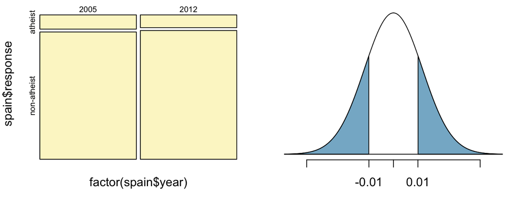

2. Is there convincing evidence that the United States has seen a change in its atheism index between 2005 and 2012?

#### 2. If in fact there has been no change in the atheism index in the countries listed in Table 4, in how many of those countries would you expect to detect a change (at a significance level of 0.05) simply by chance?

Hint: Look in the textbook index under Type 1 error.

We would expect approximately 5% of the countries to have a change simply due to chance.

#### 3. Suppose you’re hired by the local government to estimate the proportion of residents that attend a religious service on a weekly basis. According to the guidelines, the estimate must have a margin of error no greater than 1% with 95% confidence. You have no idea what to expect for p. How many people would you have to sample to ensure that you are within the guidelines?

Hint: Refer to your plot of the relationship between p and margin of error. Do not use the data set to answer this question.

Recall that the formula for the margin of error is:

$ME = z^* \sqrt{\frac{p(1-p)}{n}}$

We can solve this equation for $n$.

$ME = z^* \sqrt{\frac{p(1-p)}{n}}$ $ME^2 = z^* \frac{p(1-p)}{n}$ $n = p(1-p) \left({\frac{z^*}{ME}}\right)^2$

The most conservative estimate would use $p = 0.5$ (see the Figure for exercise 8 above). We can then solve for $n$ using $ME = 0.01$, $p = 0.5$ and $z^* = 1.96$:

$n = .5(1-.5) \left({\frac{1.96}{.01}}\right)^2$ $n = 9,604$

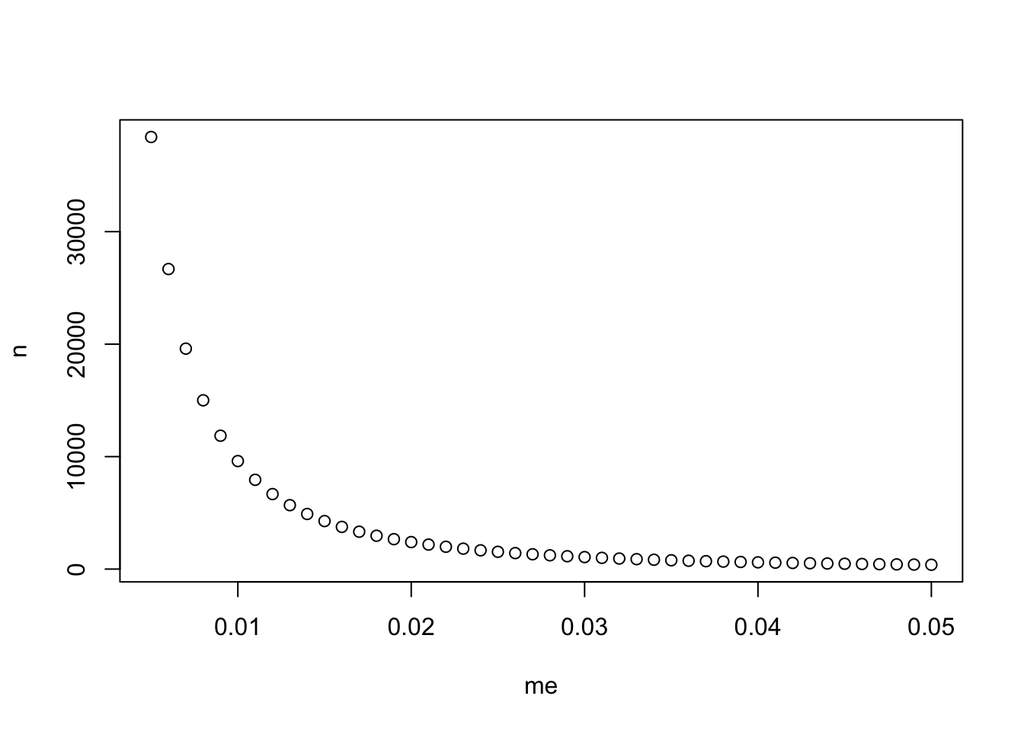

```r
me <- seq(0.005, 0.05, .001)
p <- .5
zc <- 1.96 # For 95% confidence interval
n <- p * (1 - p) * (zc / me)^2
plot(me, n)
```

The following table provides the *n*’s necessary for margin of erros ranging from 1% to 10%.

```r
me <- seq(.01, .1, .01)
print(data.frame(me=me, n=ceiling(p * (1 - p) * (zc / me)^2)), row.names=FALSE)
```

```
##    me    n
##  0.01 9604
##  0.02 2401
##  0.03 1068
##  0.04  601
##  0.05  385
##  0.06  267
##  0.07  197
##  0.08  151
##  0.09  119
##  0.10   97
```

#### 4. What concepts from the textbook are covered in this lab? What concepts, if any, are not covered in the textbook? Have you seen these concepts elsewhere, e.g. lecture, discussion section, previous labs, or homework problems? Be specific in your answer.